# Developing and Executing Error-Mitigated NISQ Algorithms Across Devices and Simulators

Cristina Cirstoiu → cristina.cirstoiu@quantinuum.com,

Dan Mills → daniel.mills@quantinuum.com

Quantinuum

Notebooks and slides → https://github.com/CQCL/IEEE_Quantum_Week

## Part Three

We have covered:

1. Explore the tools available in TKET, providing a comprehensive, feature-focused tour of the platform.
2. Introduce noise, error mitigation and Qermit.

We will cover:

1. Introduction and getting started with Qermit.
2. Out of the box error-mitigation with Qermit; `MitRes` and `MitEx`.
3. Advanced use of Qermit to fine tune and combine error-mitigation schemes.
4. Developing new error-mitigation schemes.

# Error-Mitigation & NISQ Devices

Noise:

- Noisy Intermediate-Scale Quantum → low numbers of qubits and high error rates.
- Error correction, break encryption, Grover's search → ❌

Error-Mitigation:

- Trade reduced noise for increased circuit shots.
- Moderate to no increase in qubit requirements, unlike with error-correction.

## What is Qermit?

An open-source python package for the design and execution of digital error-mitigation.

By being implemented using TKET, Qermit is platform-agnostic, so may be used:

- With a wide range of quantum hardware.
- In conjunction with several common quantum software development kits.

A common interface to the following protocols, and several variations upon them, is presently available:

- ZNE, CDR, and PEC; which mitigate for errors in expectation value calculations.
- Error-mitigation based on frame randomisation, and correction through characterisation of State Preparation And Measurement (SPAM) errors.

Graph based architecture takes advantage of the modularity of error-mitigation schemes:

- Sub-processes: circuit execution, circuit modification, model fitting, etc.
- Vertices may be amended to adapt the protocol.
- Sub-graphs and graphs may be reused and combined.

## Getting Started

`pip install qermit`

Documentation and examples → www.qerm.it.

Repository and manual → [https://github.com/CQCL/Qermit](https://github.com/CQCL/qermit).

# Shot Count Experiment

There are two types of error mitigation methods in Qermit:

- `MitRes` → modify the distribution of shots retrieved from a backend.
- `MitEx` → return a modified expectation value estimator of some observable.

MitRes and MitEx object may perform any modification of this form, or none.

- Now → experiments where the output is a collection of shots.
- Later → experiments where the output is an expectation value.

We will see experiments:

- Conducted in raw TKET, and the equivalent in Qermit.
- With and without errors.
- Where errors have been mitigated by a Qermit `MitRes`.

## Ideal Shot Count

Consider again the circuit to generate the bell pair: $$ \left| \psi \right\rangle = \frac{1}{\sqrt{2}} \left( \left| 00 \right\rangle + \left| 11 \right\rangle\right) $$

```python
from pytket import Circuit
from pytket.circuit.display import render_circuit_jupyter

circ = Circuit(2,2).H(0).CX(0,1).measure_all()
render_circuit_jupyter(circ)
```

[interactive chart not shown]

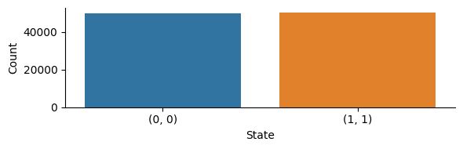

```python
from pytket.extensions.qiskit import AerBackend

n_shots = 100000
ideal_backend = AerBackend()
result = ideal_backend.run_circuit(circ, n_shots=n_shots)
plot_counts(result.get_counts())
```

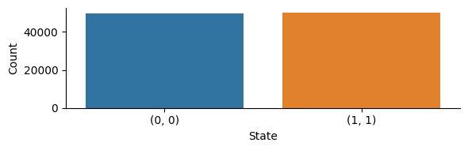

```python
from qermit import MitRes, CircuitShots

ideal_mitres = MitRes(ideal_backend)

circ_shots_list = [CircuitShots(circ, n_shots)]

result_list = ideal_mitres.run(circ_shots_list)
result_counts = result_list[0].get_counts()
plot_counts(result_counts)
```

## MitRes TaskGraph

`MitRes` and `MitEx` objects are constructed as dataflow graphs, called a `TaskGraph`.

- Each node of a `TaskGraph` is a `MitTask` object; itself a function that computes some step or sub-process of an error mitigation protocol.
- Edges of the graph move data between `MitTask` objects.
- When `run` is called, `MitTask`s are ordered and run sequentially.

## SPAM + Depolarising Noise Shot Count

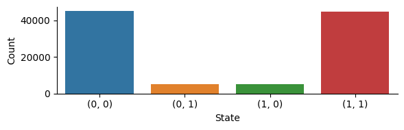

```python
from qermit.taskgraph.mitex import MitEx, gen_compiled_MitRes
from pytket.extensions.qiskit import AerBackend

noisy_backend = AerBackend(
    depolarizing_noise_model(5, 0.001, 0.01, 0.05)
)
noisy_mitres = gen_compiled_MitRes(noisy_backend, optimisation_level=0)

noisy_result_list = noisy_mitres.run(circ_shots_list)
noisy_result_counts = noisy_result_list[0].get_counts()
plot_counts(noisy_result_counts)
```

## SPAM Error-Mitigation with Qermit

```python
from qermit.spam import gen_UnCorrelated_SPAM_MitRes

spam_mr = gen_UnCorrelated_SPAM_MitRes(noisy_backend, n_shots)
spam_result_list = spam_mr.run(circ_shots_list)
spam_result_counts = spam_result_list[0].get_counts()
```

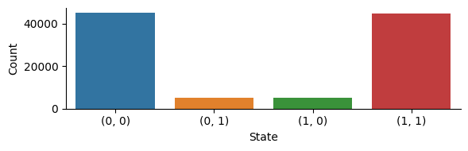

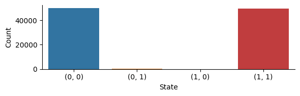

```python
plot_counts(noisy_result_counts)
plot_counts(spam_result_counts)
```

# Expectation Value Experiment

Experiments where the output is an expectation value.

We will see experiments:

- Conducted in raw TKET, and the equivalent in Qermit.
- With and without errors.
- Where errors have been mitigated by a Qermit `MitEx`.

## Ideal Expectation Value

```python
n_qubits = 4
rand_circ = random_circ(n_qubits,n_qubits,seed=23126)
render_circuit_jupyter(rand_circ)
```

[interactive chart not shown]

```python
from pytket.pauli import Pauli, QubitPauliString
from pytket import Qubit

ideal_circuit = rand_circ.copy()
ideal_circuit = ideal_backend.get_compiled_circuit(ideal_circuit)

qps = QubitPauliString(
    [Qubit(i) for i in range(n_qubits)],
    [Pauli.Z for i in range(n_qubits)]
)
ideal_result = ideal_backend.get_pauli_expectation_value(
    ideal_circuit,
    qps
)
print(f"Ideal expectation: {ideal_result}")
```

```
Ideal expectation: 0.5549662007585134
```

```python
from qermit import MitEx
from pytket.utils import QubitPauliOperator
from qermit import (
    AnsatzCircuit,
    SymbolsDict,
    ObservableExperiment,
    ObservableTracker
)

ideal_mitex = MitEx(ideal_backend)

qpo = QubitPauliOperator({qps:1})
obs_exp = ObservableExperiment(
    AnsatzCircuit(rand_circ, n_shots, SymbolsDict()),
    ObservableTracker(qpo)
)
obs_exp_list = [obs_exp]

ideal_expectation = ideal_mitex.run(obs_exp_list)
print(f"Ideal expectation: {ideal_expectation[0]}")
```

```
Ideal expectation: {(Zq[0], Zq[1], Zq[2], Zq[3]): 0.557980000000000}
```

## Noisy Expectation Value

```python
noisy_mitex = MitEx(noisy_backend)

noisy_expectation = noisy_mitex.run(obs_exp_list)
print(f"Noisy expectation: {noisy_expectation[0]}")
```

```
Noisy expectation: {(Zq[0], Zq[1], Zq[2], Zq[3]): 0.274160000000000}
```

## ZNE Error-Mitigation with Qermit

```python
from qermit.zero_noise_extrapolation import (
    gen_ZNE_MitEx, Fit, Folding
)

zne_me = gen_ZNE_MitEx(backend=noisy_backend,
                       noise_scaling_list=[9,7,5,3],
                       fit_type=Fit.exponential,
                       folding_type=Folding.circuit,
                       show_fit=True)
```

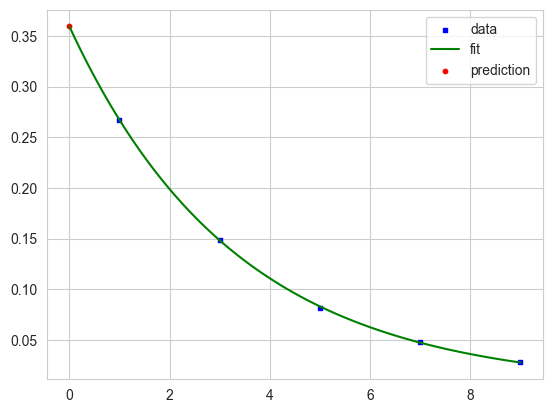

```
[{(Zq[0], Zq[1], Zq[2], Zq[3]): 0.359250338709462}]
```

```python
zne_me.run(obs_exp_list)
```

## ZNE Options and Design

There are several alternatives when building a ZNE task graph.

```python
alt_zne_me = gen_ZNE_MitEx(backend=noisy_backend,
                       noise_scaling_list=[5,4,3,2],
                       fit_type=Fit.richardson,
                       folding_type=Folding.gate,
                       show_fit=True)
```

Your favourites are available:

- Folding: `circuit`, `gate`, `odd_gate`
- Fit: `poly_exponential`, `exponential`, `polynomial`, `linear`, `richardson`

For many `MitEx` objects there are several options to personalise, without interacting directly with the `TaskGraph`.

# Advanced Qermit Use

We have seen:

- `MitRes` and `MitEx` objects.
- Use of predefined `MitRes` and `MitEx` objects, such as SPAM and ZNE.
- Personalised use of predefined objects.

We'll now look at some more advanced use cases:

- Combining error-mitigation protocols.
- Constructing original protocols.

## Combining Error-Mitigation Schemes

```python
zne_spam_me = gen_ZNE_MitEx(backend=noisy_backend,
                       noise_scaling_list=[9,7,5,3],
                       fit_type=Fit.exponential,
                       show_fit=True,
                       experiment_mitres=spam_mr)
```

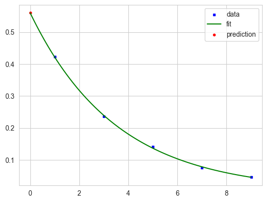

```
[{(Zq[0], Zq[1], Zq[2], Zq[3]): 0.559749211780641}]
```

```python
zne_spam_me.run(obs_exp_list)
```

## Developing Original Error-Mitigation Protocols

```python
circ = Circuit(2)
circ.X(1).measure_all()
render_circuit_jupyter(circ)
```

[interactive chart not shown]

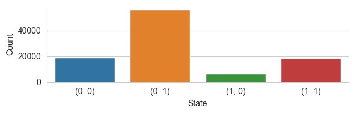

```python
noisy_backend = AerBackend(depolarizing_noise_model(5, 0, 0, 0.25))
noisy_mitres = gen_compiled_MitRes(noisy_backend, optimisation_level=0)

circ_shots_list = [CircuitShots(circ, n_shots)]

result_list = noisy_mitres.run(circ_shots_list)
result_counts = result_list[0].get_counts()
plot_counts(result_counts)
```

## Find Zero MitRes TaskGraph

```python
from pytket import OpType

def gen_find_zeros_task():

    def task(obj, circ_shots_list):
        zero_loc_list = []
        circ_size_list = []
        for circ_shot in circ_shots_list:
            not_zero_loc = []
            for command in circ_shot.Circuit.get_commands():
                if not command.op.type == OpType.Measure:
                    not_zero_loc.extend(command.qubits)
            zero_loc = [loc for loc in circ_shot.Circuit.qubits if loc not in not_zero_loc]
            zero_loc_list.append(zero_loc)
            circ_size_list.append(circ_shot.Circuit.n_qubits)
        return (circ_shots_list, zero_loc_list, circ_size_list, )

    return MitTask(
        _label="FindZeros",
        _n_out_wires=3,
        _n_in_wires=1,
        _method=task
    )
```

```python
from pytket.backends.backendresult import BackendResult

def gen_remove_ones_task():

    def task(obj, result_list, zero_loc_list, circ_size_list) -> Tuple[List[BackendResult]]:

        mitigated_result_list = []
        for result, zero_loc, circ_size in zip(result_list, zero_loc_list, circ_size_list):

            result_dict = result.to_dict()
            result_shots_array = result_dict['shots']['array']

            mitigated_result_shots_array = []
            for result_shots in result_shots_array:
                result_shot_binary = bin(result_shots[0])[2:].zfill(8)[:circ_size][::-1]
                delete_shot = False
                for zero in zero_loc:
                    if result_shot_binary[zero.index[0]] == "1": delete_shot = True
                if not delete_shot:
                    mitigated_result_shots_array.append(result_shots)

            result_dict['shots']['array'] = mitigated_result_shots_array
            mitigated_result_list.append(BackendResult.from_dict(result_dict))

        return (mitigated_result_list, )

    return MitTask(_label="RemoveOnes", _n_out_wires=1, _n_in_wires=3, _method=task)
```

```python
from qermit.taskgraph.task_graph import TaskGraph
from typing import Tuple, List
from qermit.taskgraph.mittask import MitTask

taskgraph = TaskGraph().from_TaskGraph(noisy_mitres)

taskgraph.add_wire()
taskgraph.add_wire()

taskgraph.prepend(gen_find_zeros_task())
taskgraph.append(gen_remove_ones_task())

find_zero_mitres = MitRes(noisy_mitres).from_TaskGraph(taskgraph)
```

## Find Zero MitRes TaskGraph

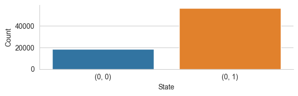

```python
result_list = find_zero_mitres.run(circ_shots_list)
result_counts = result_list[0].get_counts()
plot_counts(result_counts)
```

## Spectral Analysis MitEx TaskGraph

```python
from qermit.taskgraph.mittask import MitTask
import numpy as np

def gen_param_grid_gen_task(n_vals):

    def task(obj, obs_exp_list):

        # A parameter grid is generated for each ObservableExperiment in obs_exp_list
        param_grid_list = []
        for obs_exp in obs_exp_list:

            # List of symbols used in circuit
            sym_list = obs_exp.AnsatzCircuit.SymbolsDict.symbols_list

            # Lists of values taken by parameters, in half rotations
            param_val_list = [np.linspace(0, 2, n_vals, endpoint=False) for _ in sym_list]

            # Grids corresponding to paramert values
            param_grid = np.meshgrid(*param_val_list)
            param_grid_list.append(param_grid)

        return (obs_exp_list, param_grid_list,)

    return MitTask(_label="ParamGridGen", _n_out_wires=2, _n_in_wires=1, _method=task)
```

```python
from sympy import Symbol

a = Symbol("alpha")
b = Symbol("beta")

circ = Circuit(2)
circ.H(0).H(1).Rz(a, 0).Rz(b, 1).H(0).H(1)
render_circuit_jupyter(circ)
```

[interactive chart not shown]

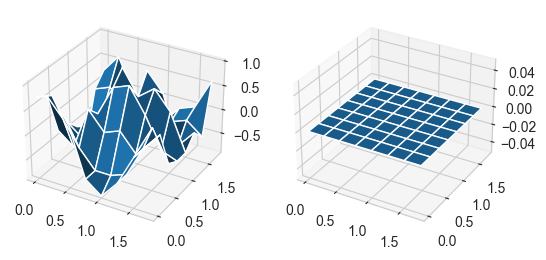

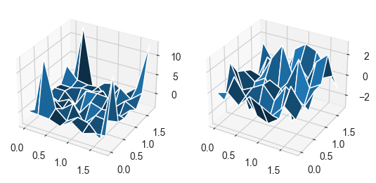

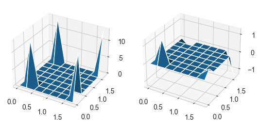

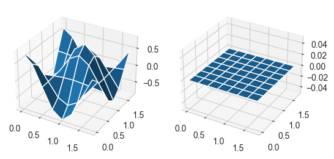

```
[array([[ 0.81141747+0.j,  0.55450515+0.j, -0.02722876+0.j,
         -0.59301243+0.j, -0.81141747+0.j, -0.55450515+0.j,
          0.02722876+0.j,  0.59301243+0.j],
        [ 0.53737712+0.j,  0.37047117+0.j, -0.01345176+0.j,
         -0.38949484+0.j, -0.53737712+0.j, -0.37047117+0.j,
          0.01345176+0.j,  0.38949484+0.j],
        [-0.05145146+0.j, -0.03057979+0.j,  0.0082051 +0.j,
          0.04218355+0.j,  0.05145146+0.j,  0.03057979+0.j,
         -0.0082051 +0.j, -0.04218355+0.j],
        [-0.61014047+0.j, -0.41371753+0.j,  0.02505552+0.j,
          0.44915139+0.j,  0.61014047+0.j,  0.41371753+0.j,
         -0.02505552+0.j, -0.44915139+0.j],
        [-0.81141747+0.j, -0.55450515+0.j,  0.02722876+0.j,
          0.59301243+0.j,  0.81141747+0.j,  0.55450515+0.j,
         -0.02722876+0.j, -0.59301243+0.j],
        [-0.53737712+0.j, -0.37047117+0.j,  0.01345176+0.j,
          0.38949484+0.j,  0.53737712+0.j,  0.37047117+0.j,
         -0.01345176+0.j, -0.38949484+0.j],
        [ 0.05145146+0.j,  0.03057979+0.j, -0.0082051 +0.j,
         -0.04218355+0.j, -0.05145146+0.j, -0.03057979+0.j,
          0.0082051 +0.j,  0.04218355+0.j],
        [ 0.61014047+0.j,  0.41371753+0.j, -0.02505552+0.j,
         -0.44915139+0.j, -0.61014047+0.j, -0.41371753+0.j,
          0.02505552+0.j,  0.44915139+0.j]])]
```

```python
sym_dict = SymbolsDict().symbols_from_dict({a:0.3, b:1.25})
qubit_pauli_string = QubitPauliString(
    [Qubit(0), Qubit(1)], [Pauli.Z, Pauli.Z]
)
ansatz_circuit = AnsatzCircuit(circ, 16, sym_dict)
exp = ObservableExperiment(
        ansatz_circuit,
        ObservableTracker(QubitPauliOperator({qubit_pauli_string: 1.0})),
    )

experiment_taskgraph.run([exp])
```

# Conclusion

In the last hour we have:

1. Introduction and getting started with Qermit.
2. Out of the box error-mitigation with Qermit; `MitRes` and `MitEx`.
3. Advanced use of Qermit to fine tune and combine error-mitigation schemes.
4. Developing new error-mitigation schemes.

In the last three hours we have:

1. Explore the tools available in TKET, providing a comprehensive, feature-focused tour of the platform.
2. Introduce noise and error mitigation.
3. Exemplify out of the box and advanced usage of Qermit for the composition and design of error-mitigation protocols.